# BUSS6002 - Data Science in Business

#### Pre-Tutorial Checklist

1. Complete Tasks 1 and 2 from week 6
2. Complete up to but NOT including Exercise 1

# Tutorial 7 - Classification

Classification is the task of assigning a category or label to an observation. A classifier is an algorithm that implements classification. There are two main types of classification: binary and multiclass.

In general it is a poor idea to use linear regression algorithms for classification tasks. A reression learns a continuous output variable. In other words regression is good at estimating the value of something e.g. price, weight, height etc. If we were to use regression for a binary classification we might end up with prediction values of $0.1, 0.2, \dots, 0.7$ etc, which does not suit the goal of predicting either a $0$ or a $1$.

Classification on the other hand only produces discrete outputs. There are many ways to do this. In this tutorial we will focus on Logistic Regression.

## Logistic Regression

One way to approach Classification is to use probability:

```
If we can calculate the probabilty of an observation belonging to each class we can assign it to the class with the highest probability.
```

Therefore we need a function or model that takes an observation/feature vector as input and returns a probability. We will focus on the binary classification case. Therefore we can simplify our search to finding the probability, $p$, for the "success" case. The probability of the other class can be calculated using the complentary nature of probability ($1- p$).

To summarise, we need a function that:

- Returns value in the the interval $[0, 1]$ (for a valid probability)
- Accepts real valued inputs that are on the interval $[-\infty, +\infty]$
- Accepts scalar and vector inputs

### Logistic Function

It turns out that the Logistic Function is a function that meets all the requirements.

$$y = \frac {1}{1+e^{-t}}$$

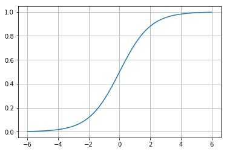

```python
%matplotlib inline
import matplotlib.pyplot as plt
import numpy as np

# Create a vector of equally spaced x values with linspace
x = np.linspace(-6, 6, 1000)

# Evaluate the Logistic function for each value in x
y = 1 / (1 + np.exp(-x))

fig = plt.figure()

plt.plot(x, y)
plt.grid()

plt.show()
```

We can control the location of the x intercept $x_0$ and the steepness of the curve via $k$

$$y = \frac {1}{1+e^{-k(x - x_0)}}$$

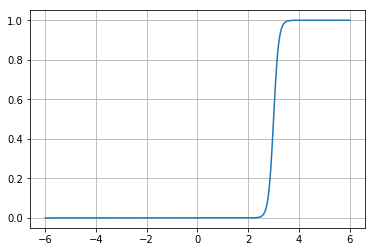

```python
x_0 = 3
k = 10

# Create a vector of equally spaced x values with linspace
x = np.linspace(-6, 6, 1000)

# Evaluate the Logistic function for each value in x
y = 1 / (1 + np.exp(-k*(x - x_0)))

fig = plt.figure()

plt.plot(x, y)
plt.grid()

plt.show()
```

Notice that the parameterisation with $x_0$ and $k$ looks a little similiar to a linear model $\beta_0 + \beta_1 x$. In fact if we set $t = \beta_0 + \beta_1 x$ we can find parameters that best fit our data.

**Simple Logistic Regression model** $$y = \frac {1}{1+e^{-(\beta_0 + \beta_1 x)}}$$

Notice that the logistic function is non-linear and more flexible than a linear regression, which can improve classification accuracy and is often more robust to outliers.

### Example 1 - Univariate

Lets say we have some data about students someone passing BUSS6002 and the number of hours they studied. We would like to predict whether they pass (success case) or fail.

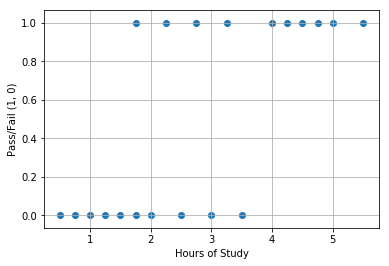

```python
x_hours = np.array([0.50, 0.75, 1.00, 1.25, 1.50, 1.75, 1.75, 2.00, 2.25, 2.50, 2.75, 3.00, 3.25, 3.50, 4.00, 4.25, 4.50, 4.75, 5.00, 5.50])

y_pass = np.array([0, 0, 0, 0, 0, 0, 1, 0, 1, 0, 1, 0, 1, 0, 1, 1, 1, 1, 1, 1])

fig = plt.figure()

plt.scatter(x_hours, y_pass)
plt.grid()

plt.xlabel("Hours of Study")
plt.ylabel("Pass/Fail (1, 0)")

plt.show()
```

#### Linear Regression (Counter Example)

This is a counter example. Do not use linear regression for classification.

Notice that linear regression is:

- Unbounded, output is from $[-\infty, \infty]$
- Not really robust to outliers
- Inflexible decision boundary

```python
# Build and fit a linear regression

import statsmodels.api as sm

x_with_intercept = sm.add_constant(x_hours, prepend=True)

model = sm.OLS(y_pass, x_with_intercept)

results = model.fit()
```

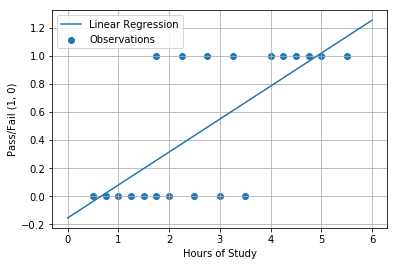

```python
# Plot the linear regression prediction

x_points = np.linspace(0, 6, 100)
y_linear_model = results.predict(sm.add_constant(x_points, prepend=True))

fig = plt.figure()

plt.scatter(x_hours, y_pass, label = "Observations")

# Plot linear regression model
plt.plot(x_points, y_linear_model, label = "Linear Regression")

plt.grid()
plt.xlabel("Hours of Study")
plt.ylabel("Pass/Fail (1, 0)")
plt.legend()

plt.show()
```

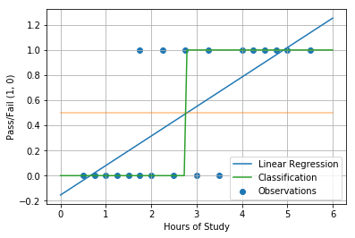

```python
# Plot the linear regression prediction

classification = (y_linear_model > 0.5).astype(int)

fig = plt.figure()

plt.scatter(x_hours, y_pass, label = "Observations")

# Plot linear regression model
plt.plot(x_points, y_linear_model, label = "Linear Regression")

# Plot the decision boundary
plt.plot(x_points, np.ones(100) * 0.5, alpha = 0.5) # We classify any points with p > 0.5 as success
plt.plot(x_points, classification, label = "Classification")

plt.grid()
plt.xlabel("Hours of Study")
plt.ylabel("Pass/Fail (1, 0)")
plt.legend()

plt.show()
```

### Exercise 1 - Prediction

1. According to the linear model, what is the probability of passing after 6 hours of study?
2. Is the result from 1. reasonable? Why or why not?

### Logistic Regression

### Documentation - LogisticRegression

https://scikit-learn.org/stable/modules/generated/sklearn.linear_model.LogisticRegression.html

```python
from sklearn.linear_model import LogisticRegression

# Create a logistic regression object
# I'm using the hyper-parameter C to make the regression fit "tighter" to the data
# We will discuss how to optimise hyper parameters later
# http://scikit-learn.org/stable/modules/generated/sklearn.linear_model.LogisticRegression.html
log_reg = LogisticRegression(C = 1e16, solver = 'liblinear')

# Fit the object to the data
log_reg.fit(x_hours.reshape(-1, 1), y_pass)

# Create vector of x values to evaluate the model
x_points = np.linspace(0, 6, 100)

# predict_proba returns the probabilities of each class. Column 0 is class=0, column 1 is class=1 (sucess)
y_log_model = log_reg.predict_proba(x_points.reshape(-1, 1))[:,1]
```

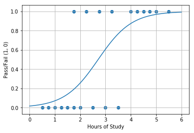

```python
fig = plt.figure()

plt.scatter(x_hours, y_pass)
plt.plot(x_points, y_log_model)
plt.grid()

plt.xlabel("Hours of Study")
plt.ylabel("Pass/Fail (1, 0)")

plt.show()
```

[figure not shown]

```python
# Plot the logistic regression prediction
classification = log_reg.predict(x_points.reshape(-1, 1))

fig = plt.figure()

plt.scatter(x_hours, y_pass, label = "Observations")

# Plot logistic regression model
plt.plot(x_points, y_log_model, label = "Logistic Regression")

# Plot the decision boundary
plt.plot(x_points, np.ones(100) * 0.5, alpha = 0.5) # We classify any points with p > 0.5 as success
plt.plot(x_points, classification, label = "Classification")

plt.grid()
plt.xlabel("Hours of Study")
plt.ylabel("Pass/Fail (1, 0)")
plt.legend()

plt.show()
```

#### Estimated Logistic Regression Parameters

We can access the model parameters via the attributes of the logisitc regression model object. We end up with a logisitic regression of the following form

$$y = \frac {1}{1+e^{-(-4.1 + 1.5 x)}}$$

```python
log_reg.intercept_
```

```
array([-4.07771337])
```

```python
log_reg.coef_
```

```
array([[1.5046454]])
```

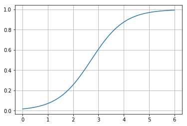

```python
x_points = np.linspace(0, 6, 100)

y_log_model_manual = 1 / (1 + np.exp(-(log_reg.intercept_[0] + log_reg.coef_[0][0] * x_points )))

fig = plt.figure()

plt.plot(x_points, y_log_model_manual)
plt.grid()

plt.show()
```

#### Linear Regression vs Logistic Regression

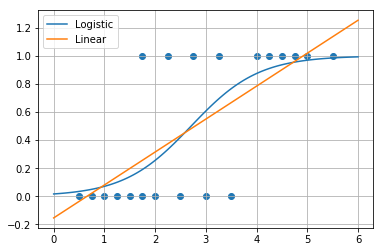

```python
fig = plt.figure()

plt.scatter(x_hours, y_pass)
plt.plot(x_points, y_log_model, label = "Logistic")
plt.plot(x_points, y_linear_model, label  ="Linear")

plt.grid()
plt.legend()

plt.show()
```

### Example 2 - Multivariate

In the previous example we only had a single explanatory variable, therefore we built a univariate logistic regression. In this example we will have multiple explanatory variables resulting in a multivariate logistic regression.

$$y = \frac {1}{1+e^{-(\beta_0 + \beta_1 x_1 + \beta_2 x_2 + \dots + \beta_p x_p)}}$$

We will use the Breast Cancer Wisconsin (Diagnostic) Data Set which is built into sklearn https://archive.ics.uci.edu/ml/datasets/Breast+Cancer+Wisconsin+(Diagnostic)

### Documentation - load_breast_cancer

https://scikit-learn.org/stable/modules/generated/sklearn.datasets.load_breast_cancer.html

The dataset contains observations of inidividuals with the following data:

- Diagnosis (Malignant (0), Benign (1))
- 3x10 (30) features about the potential cancer samples

```python
from sklearn.datasets import load_breast_cancer

data_dict = load_breast_cancer()

# You can print out the full description using the next line.
print(data_dict.DESCR)
```

```
.. _breast_cancer_dataset:

Breast cancer wisconsin (diagnostic) dataset
--------------------------------------------

**Data Set Characteristics:**

    :Number of Instances: 569

    :Number of Attributes: 30 numeric, predictive attributes and the class

    :Attribute Information:
        - radius (mean of distances from center to points on the perimeter)
        - texture (standard deviation of gray-scale values)
        - perimeter
        - area
        - smoothness (local variation in radius lengths)
        - compactness (perimeter^2 / area - 1.0)
        - concavity (severity of concave portions of the contour)
        - concave points (number of concave portions of the contour)
        - symmetry
        - fractal dimension ("coastline approximation" - 1)

        The mean, standard error, and "worst" or largest (mean of the three
        largest values) of these features were computed for each image,
        resulting in 30 features.  For instance, field 3 is Mean Radius, field
        13 is Radius SE, field 23 is Worst Radius.

        - class:
                - WDBC-Malignant
                - WDBC-Benign

    :Summary Statistics:

    ===================================== ====== ======
                                           Min    Max
    ===================================== ====== ======
    radius (mean):                        6.981  28.11
    texture (mean):                       9.71   39.28
    perimeter (mean):                     43.79  188.5
```

[output cut: 63 more lines]

```
ftp ftp.cs.wisc.edu
cd math-prog/cpo-dataset/machine-learn/WDBC/

.. topic:: References

   - W.N. Street, W.H. Wolberg and O.L. Mangasarian. Nuclear feature extraction
     for breast tumor diagnosis. IS&T/SPIE 1993 International Symposium on
     Electronic Imaging: Science and Technology, volume 1905, pages 861-870,
     San Jose, CA, 1993.
   - O.L. Mangasarian, W.N. Street and W.H. Wolberg. Breast cancer diagnosis and
     prognosis via linear programming. Operations Research, 43(4), pages 570-577,
     July-August 1995.
   - W.H. Wolberg, W.N. Street, and O.L. Mangasarian. Machine learning techniques
     to diagnose breast cancer from fine-needle aspirates. Cancer Letters 77 (1994)
     163-171.
```

```python
data_dict.keys()
```

```
dict_keys(['data', 'target', 'target_names', 'DESCR', 'feature_names', 'filename'])
```

```python
data_dict.target_names
```

```
array(['malignant', 'benign'], dtype='<U9')
```

```python
data_dict.data.shape
```

```
(569, 30)
```

#### Building the Model

```python
log_res_multi = LogisticRegression(C = 1e19, solver = 'liblinear')

log_res_multi.fit(data_dict.data, data_dict.target)
```

```
LogisticRegression(C=1e+19, class_weight=None, dual=False, fit_intercept=True,
          intercept_scaling=1, max_iter=100, multi_class='warn',
          n_jobs=None, penalty='l2', random_state=None, solver='liblinear',
          tol=0.0001, verbose=0, warm_start=False)
```

#### Predicting

Lets pick a random observation from our dataset and check if our prediction is correct.

```python
obs_idx = 20

obs = data_dict.data[obs_idx, :]

prediction = log_res_multi.predict(obs.reshape(1, 30))
```

```python
obs_class = data_dict.target[obs_idx]
```

```python
print("True class: {0}".format(obs_class))
print("Predicted class: {0}".format(prediction[0]))
```

```
True class: 1
Predicted class: 1
```

### Exercise 2 - Prediction

1. What is our univariate model's prediction for a student who studies 3.01 hours a day?
2. According to our multivariate model, what is the probability of having breast cancer given the following list of attributes?:

   `np.array([16.74, 21.59, 110.1, 869.5, 0.0961, 0.1336, 0.1348, 0.06018, 0.1896, 0.05656, 0.4615, 0.9197, 3.008, 45.19, 0.005776, 0.02499, 0.03695, 0.01195, 0.02789, 0.002665, 20.01, 29.02, 133.5, 1229.0, 0.1563, 0.3835, 0.5409, 0.1813, 0.4863, 0.08633])`

## Relationship to Linear Regression

$$ log \left( \frac{y}{1 - y} \right ) = \beta_0 + \beta_1 x $$

where $y$ is the logistic function

$$y = \frac {1}{1+e^{-(\beta_0 + \beta_1 x)}}$$

Sometimes $y$ is written as $p(x)$ since it is the probability of the success case given $x$.

## Evaluating Classification Performance

There are many metrics that you can use to evaluate the classification accuracy. Scikit-learn has implemented many for us to use.

### Documentation - Classification Metrics

http://scikit-learn.org/stable/modules/model_evaluation.html#classification-metrics

These metrics work by comparing our model's predicted values to known labels, so you always need the ground-truth classification for your data when evaluating classification performance.

The simplest approach is to use a confusion matrix and the classification report, which shows multiple metrics at once!

The confusion matrix keeps track of our model's hits and misses, and shows the number of true positive, false positive, false negative and true negative classifications. Ideally we want a diagonal matrix, meaning only true positive and true negative classifications.

[figure not shown]

To produce a confusion matrix for our model, we need to first generate some prediction data. We then use the `confusion_matrix` function from the sklearn metrics library.

### Documentation - Confusion_matrix

https://scikit-learn.org/stable/modules/generated/sklearn.metrics.confusion_matrix.html

```python
from sklearn.metrics import confusion_matrix

y_pred = log_res_multi.predict(data_dict.data)

print(confusion_matrix(data_dict.target, y_pred))
```

```
[[199  13]
 [  6 351]]
```

If we want to handle true negatives, false positives, false negatives and true positives individually, we can unroll the confusion matrix into individual variables:

```python
tn, fp, fn, tp = confusion_matrix(data_dict.target, y_pred).ravel()

(tn, fp, fn, tp)
```

```
(199, 13, 6, 351)
```

More classification metrics can be accessed using the `classification_report` function from the sklearn metrics library.

### Documentation - classification_report

https://scikit-learn.org/stable/modules/generated/sklearn.metrics.classification_report.html

Again, we need to supply the function with target values and predicted values.

```python
from sklearn.metrics import classification_report

print(classification_report(data_dict.target, y_pred))
```

```
              precision    recall  f1-score   support

           0       0.97      0.94      0.95       212
           1       0.96      0.98      0.97       357

   micro avg       0.97      0.97      0.97       569
   macro avg       0.97      0.96      0.96       569
weighted avg       0.97      0.97      0.97       569
```

Understanding these metrics is straightforward if we understand the confusion matrix. `Precision` (or positive predictive value) is simply the proportion of all points identified as positives that were correctly classified. We can write this as:

$$Precision = \frac{TP}{TP+FP}$$

If by "positive" we mean our `1` class (second row of the classification report above), we can easily calculate the precision:

```python
tp / (tp + fp)
```

```
0.9642857142857143
```

If instead by "positive" we mean the `0` class (first row of the classification report), this becomes:

```python
tn / (tn + fn)
```

```
0.9707317073170731
```

`Recall` (or true positive rate) is the proportion of actual positives that were correctly classified by our model. We can express this as:

$$Recall = \frac{TP}{TP + FN}$$

The `F1` score is the *harmonic mean* of precision and recall, and reaches its best value at 1 (perfect precision and recall) and worst at 0. The F1 score can be expressed as:

$$F_1 = \left(\frac{Recall^{-1}+Precision^{-1}}{2}\right)^{-1}$$

### Exercise 3 - Classification metrics

1. What is the condition for perfect precision ($Precision = 1$)?
2. What is the condition for perfect recall?
3. Given 1. and 2. what is the condition for a perfect F1 score?
4. What does the confusion matrix look like for a model with $F_1 = 1$?

## Probability vs Class Assignment

A logistic regression model returns the probability of the success case. The formula is $$y = \frac {1}{1+e^{-(\beta_0 + \beta_1 x)}}$$ where $y$ is the proability.

In order to assign a new data point to a class we must assign it to the class with the highest proability. Since we are dealing with a binary classification problem there are only two classes. Also the probability of one class is complementary to the other. So if the probability of class 1 (success) is $> 50\%$ then we assign the data point to class 1. If it it less than $50\%$ we assign it to class 0.

To view the calculated probability of our model we can use the predict_proba function. Since our first model is univariate we just input a single x value.

```python
# Probability of class 0 (y = 0 i.e. fail) and class 1 (y = 1, pass)  when study hours = 0.5
probabilities = log_reg.predict_proba(np.array([[0.5]]))

print(probabilities)
```

```
[[0.96528966 0.03471034]]
```

```python
print("The probability of failing if you study 0.5 hours/week is: {0:.2f}".format(probabilities[0,0]))

print("The probability of passing if you study 0.5 hours/week is: {0:.2f}".format(probabilities[0,1]))
```

```
The probability of failing if you study 0.5 hours/week is: 0.97
The probability of passing if you study 0.5 hours/week is: 0.03
```

To view the class prediction we just use the predict function

```python
class_prediction = log_reg.predict(np.array([[0.5]]))

# The predicted class is 0, which means the student is most likely to fail
print(class_prediction)
```

```
[0]
```